# Prediction of barbell lifts

6/6/2017

## Background

Using devices such as Jawbone Up, Nike FuelBand, and Fitbit it is now possible to collect a large amount of data about personal activity relatively inexpensively. These type of devices are part of the quantified self movement – a group of enthusiasts who take measurements about themselves regularly to improve their health, to find patterns in their behavior, or because they are tech geeks. One thing that people regularly do is quantify how much of a particular activity they do, but they rarely quantify how well they do it.

## Data

The training data for this project are available here:

https://d396qusza40orc.cloudfront.net/predmachlearn/pml-training.csv

The test data are available here:

https://d396qusza40orc.cloudfront.net/predmachlearn/pml-testing.csv

The data for this project come from this source: http://groupware.les.inf.puc-rio.br/har

## Goal

In this project, the goal will be to use data from accelerometers on the belt, forearm, arm, and dumbell of 6 participants. They were asked to perform barbell lifts correctly and incorrectly in 5 different ways. The goal of the project is to predict the manner in which they did the exercise. (This is the “classe” variable in the training set.)

## Data cleaning

Load libraries

```r
library(caret)
library(car)
library(plyr)
library(dplyr)
set.seed(12345)
```

Load data

```r
train_df <- read.csv("./pml-training.csv",
                     na.strings=c("","NA", "#DIV/0!"))
test_df <- read.csv("./pml-testing.csv")


#str(train_df)
```

Check dimensions, filter out NA’s and remove unwanted columns.

```r
dim(train_df)
```

```
## [1] 19622   160
```

```r
# # check for na
# ncols <- ncol(train_df)
# for (i in 1:ncols){
#     print(paste(i, mean(is.na(train_df[,i]))))
# }
# print(ncols)

new_train_df <- train_df %>%
    select(which(colMeans(is.na(.))<0.5)) %>%
    filter(rowMeans(is.na(.)) < 1) %>%
    select(-X, -user_name, -raw_timestamp_part_1,
           -raw_timestamp_part_2, -cvtd_timestamp,
           -num_window, -new_window)

dim(new_train_df)
```

```
## [1] 19622    53
```

```r
table(new_train_df[, 53])
```

```
##
##    A    B    C    D    E
## 5580 3797 3422 3216 3607
```

## Data exploration

```r
total_feature <- which(grepl("^total",
                             colnames(new_train_df),
                             ignore.case = FALSE))
total_feature
```

```
## [1]  4 17 30 43
```

Since there are a lot of data points, sampling a subset and plotting them to get a feel for the data.

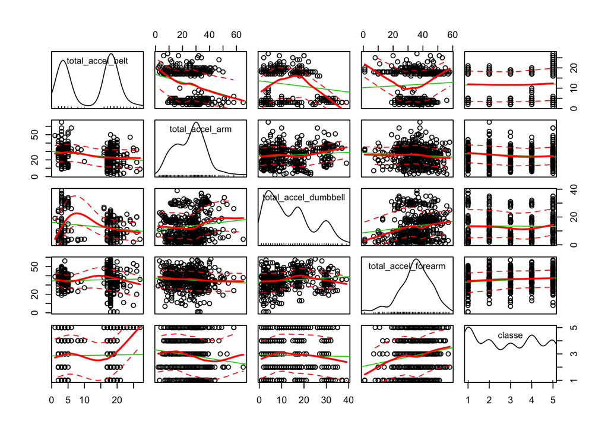

```r
sample_train <- new_train_df[sample(nrow(new_train_df[, ]), 500),]
sample_train <- sample_train %>%
    select(c(total_feature, 53))

scatterplotMatrix(sample_train)
```

Checking for data columns with near zero variance

```r
nzV <- nearZeroVar(new_train_df[1:52], saveMetrics=TRUE)
if (any(nzV$nzV)) nzV else message("None with zero variance")
```

```
## None with zero variance
```

Checking for highly correlated variables.

```r
# # for our case
tmp_df <- cor(new_train_df[1:52])
tmp_op <- findCorrelation(tmp_df, cutoff = 0.99)
tmp_op <- sort(tmp_op)
reduced_data <- new_train_df[, -c(tmp_op)]
dim(reduced_data)
```

```
## [1] 19622    52
```

## Analysis

Using caret package. Partioning the training data into a training and test sample to (i) train the models and (ii) to obtain an estimate of the in-sample and out-of sample errors.

```r
inTrain <- createDataPartition(y = new_train_df$classe,
                               p = 0.75,
                               times = 1,
                               list = FALSE)
training <- new_train_df[inTrain, ]
testing <- new_train_df[-inTrain, ]
```

Do some preprocessing of the data:

```r
# Standardizing the data
preProcMethod = c("center", "scale")

# set options for 10 fold cross validation
tctrl <- trainControl(method = "cv", number = 10,
                      verboseIter = TRUE)
# Formula for the training
formula <- classe ~ .
```

This is a classification problem and there are several model options which can be used for prediction. The ones tested in this report are (i) classification tree (ii) random forest (iii) boost and (iv) linear discriminant analysis. Training the models one by one.

1. Train a classification tree:

```r
set.seed(34543)
modelFitRpart <- train(formula, data = new_train_df,
                       method="rpart",
                       preProcess = preProcMethod,
                       trControl = tctrl,
                       subset = inTrain)
```

2. Train a random forest:

```r
set.seed(34543)
modelFitRF <- train(formula, data = new_train_df,
                    method="rf",
                    preProcess = preProcMethod,
                    trControl = tctrl,
                    subset = inTrain,
                    prox = TRUE)
```

3. Train a boost model:

```r
set.seed(34543)
modelFitBoost <- train(formula, data = new_train_df,
                       method = "gbm",
                       preProcess = preProcMethod,
                       trControl = tctrl,
                       subset = inTrain,
                       verbose = FALSE)
```

4. and finally train a LDA model:

```r
set.seed(34543)
modelFitLDA <- train(formula, data = new_train_df,
                     method = "lda",
                     preProcess = preProcMethod,
                     trControl = tctrl,
                     subset = inTrain)
```

Since these evaluations can take a long time, save the variables in a file. This also aids in making the report.

```r
save.image(file = "project.RData")
```

(For making the document, loading data from a saved session.)

```r
load("project.Rdata")
```

### In-sample error

Based on the partitioning of the training dataset, we can estimate the in-sample error.

```r
# Accuracy comparison
models_considered <- c("Class. Tree",
           "Random Forest",
           "Boost",
           "LDA")

model_Accuracy <- c(max(modelFitRpart$results$Accuracy),
              max(modelFitRF$results$Accuracy),
              max(modelFitBoost$results$Accuracy),
              max(modelFitLDA$results$Accuracy))

model_Kappa <- c(max(modelFitRpart$results$Kappa),
           max(modelFitRF$results$Kappa),
           max(modelFitBoost$results$Kappa),
           max(modelFitLDA$results$Kappa))

model_performance_summary <- cbind(models_considered,
                                   model_Accuracy,
                                   model_Kappa)

model_performance_summary
```

```
##      models_considered model_Accuracy      model_Kappa
## [1,] "Class. Tree"     "0.525945376168512" "0.383390660949924"
## [2,] "Random Forest"   "0.992662437706234" "0.990717704828566"
## [3,] "Boost"           "0.962834247389367" "0.95297775820358"
## [4,] "LDA"             "0.700435022362648" "0.620747174682591"
```

### Out-of sample error

```r
#Put all models into a list
multi_models <- list(rpart = modelFitRpart,
                     rf = modelFitRF,
                     gbm = modelFitBoost,
                     lda = modelFitLDA)

#Run prediction across models
multi_predict <- predict(multi_models, testing)
#Create confusion matrix for each model
saveCM <- lapply(multi_predict, FUN = confusionMatrix,
       reference = testing$classe,
       positive = "yes")


predict_Accuracy <- c(saveCM$rpart$overall[1],
                    saveCM$rf$overall[1],
                    saveCM$gbm$overall[1],
                    saveCM$lda$overall[1])

predict_Kappa <- c(saveCM$rpart$overall[2],
                      saveCM$rf$overall[2],
                      saveCM$gbm$overall[2],
                      saveCM$lda$overall[2])

predict_performance_summary <- cbind(models_considered,
                                   predict_Accuracy,
                                   predict_Kappa)
predict_performance_summary
```

```
##          models_considered predict_Accuracy    predict_Kappa
## Accuracy "Class. Tree"     "0.497145187601958" "0.342859248120889"
## Accuracy "Random Forest"   "0.991231647634584" "0.988904876383438"
## Accuracy "Boost"           "0.960848287112561" "0.950449232234333"
## Accuracy "LDA"             "0.70615823817292"  "0.627848101932443"
```

The Random Forest method out-scores all the other models. It has an in-sample error of only 0.74% and an out-of sample error of 0.88%.

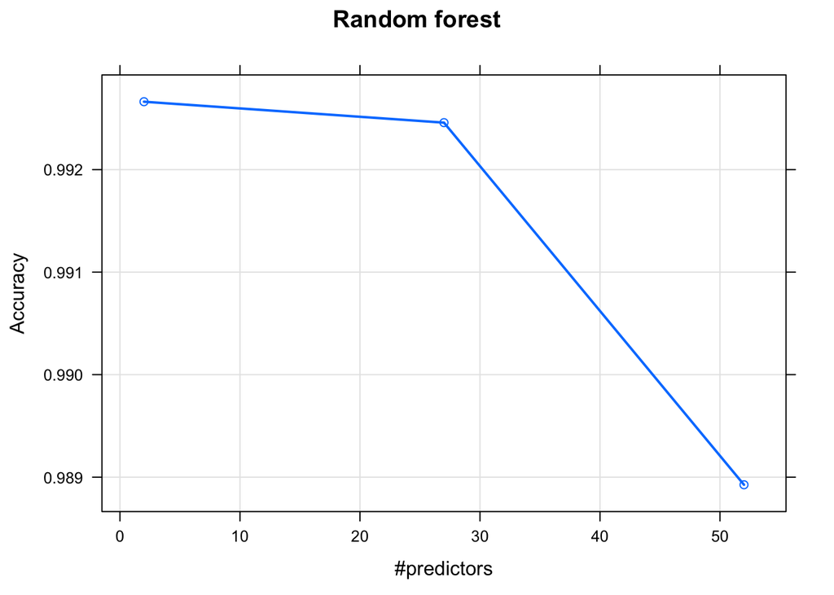

```r
plot(modelFitRF, log = "y", lwd = 2,
     main = "Random forest",
     xlab = "#predictors",
     ylab = "Accuracy")
```

Summary of the final model (Random Forest):

```r
varImp(modelFitRF)
```

```
## rf variable importance
##
##   only 20 most important variables shown (out of 52)
##
##                      Overall
## roll_belt             100.00
## yaw_belt               83.89
## magnet_dumbbell_z      71.40
## pitch_forearm          63.25
## pitch_belt             62.88
## magnet_dumbbell_y      61.35
## magnet_dumbbell_x      52.80
## roll_forearm           50.86
## accel_dumbbell_y       45.56
## accel_belt_z           44.27
## magnet_belt_z          43.38
## roll_dumbbell          42.20
## magnet_belt_y          41.67
## accel_dumbbell_z       38.99
## roll_arm               35.19
## accel_forearm_x        33.17
## yaw_dumbbell           30.36
## accel_dumbbell_x       30.01
## gyros_belt_z           29.37
## total_accel_dumbbell   28.08
```

```r
modelFitRF$finalModel
```

```
##
## Call:
##  randomForest(x = x, y = y, mtry = param$mtry, proximity = TRUE)
##                Type of random forest: classification
##                      Number of trees: 500
## No. of variables tried at each split: 2
##
##         OOB estimate of  error rate: 0.63%
## Confusion matrix:
##      A    B    C    D    E  class.error
## A 4182    3    0    0    0 0.0007168459
## B   18 2825    5    0    0 0.0080758427
## C    0   16 2549    2    0 0.0070120764
## D    0    0   40 2370    2 0.0174129353
## E    0    0    0    6 2700 0.0022172949
```

Thus it is chosen at the candidate model to do the final prediction on the test data.

## Apply to test conditions

```r
## Now let's apply to the test data
predictionRF <- predict(modelFitRF, test_df)
print(predictionRF)
```

```
##  [1] B A B A A E D B A A B C B A E E A B B B
## Levels: A B C D E
```

## Conclusion

For this dataset, the Random Forest method resulted in superb accuracy.